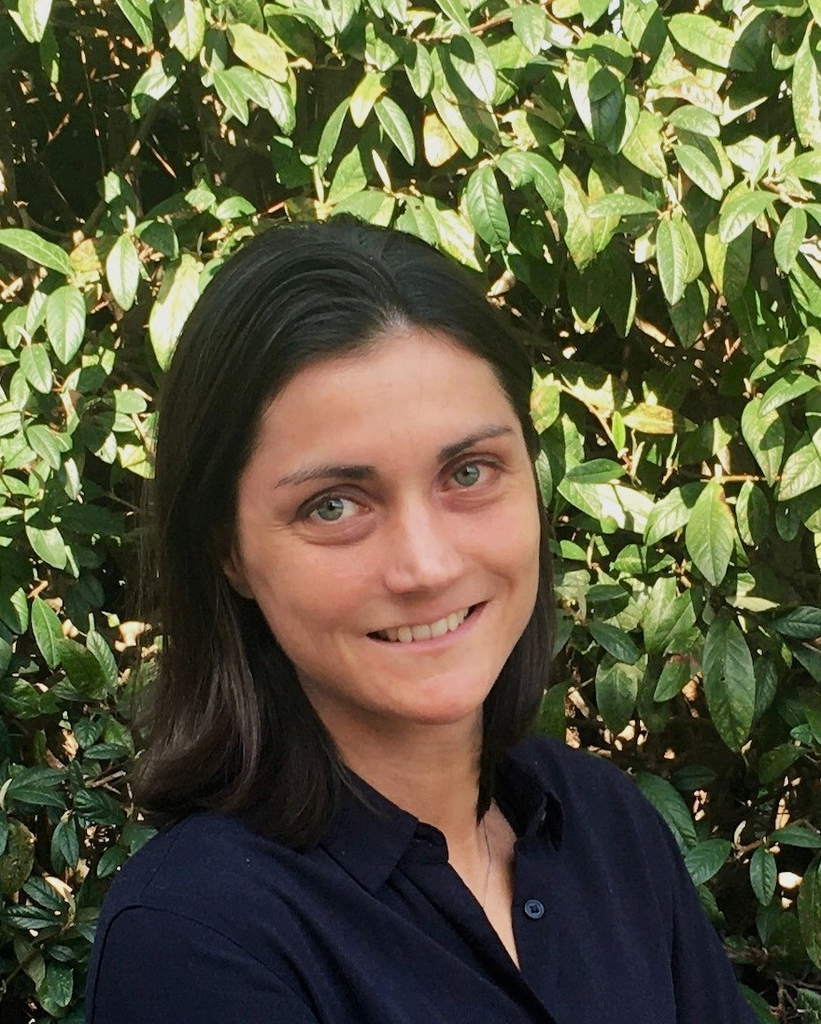

# Claire Benard

## Bio

I’m a data scientist, keen to use data to solve problems that matter. My earlier work experience was in national and international charities and although I’m now a consultant, I still volunteer for [DataKind UK](https://datakind.org.uk/).

## Blog

*Most of my blogs talk about data in the charity sector, ethics and strategy.*

[**6 things funders can do to support the responsible use of data**](https://urbanhealth.org.uk/insights/author/clairebenard) | Impact on Urban Health (October, 21)

[**Using Data Beyond Monitoring & Evaluation**](https://data4goodfest.org.uk/beyond-mande/) | Data4good Fest (July, 21)

[**Three lessons I learned from a week in a tech start up**](https://blogs.ncvo.org.uk/2018/03/12/three-lessons-i-learned-from-a-week-in-a-tech-start-up/) | NCVO (March, 18)

[**Using R to produce innovative, quick and reproducible evidence**](https://vimeo.com/209798429) | MERL Tech (March, 17)

## Projects

**Charity classifier** | [Check out the code](https://github.com/ClaireBenard/charity-classifier)  
*When registering with the Commission, charities must declare their sector of activity. This is a tick box with 16 options. Due to the nature of the sector, most organisations tick at least 2, and some as many as all 16 boxes.* *This work attempts to classify organisations based on the legal definition of their activity (their charitable object). Given the wording of their object, the model returns the most likely sector of activity.*

**Predicting waste to reduce it** | [Check out the code](https://github.com/darenasc/data_world_league_2022/blob/main/notebooks/k-nearest-teammates-submission-nb.ipynb)  
*This project was the first phase of the [World Data League](https://www.worlddataleague.com) competition. We analysed trends in waste production to help understand how to reduce it and how to optimise waste collection*